# Which quantiles of a continuous distribution can one estimate with more precision?

Hongyu Dai

2021/10/23

# Introduction

The median is an important quantity in data analysis. It represents the median value of the data distribution. Estimates of the median, however, have a degree of uncertainty because:

1. the estimates are calculated from a finite sample
2. the data distribution of the underlying data is generally unknown.

One important roles of a data scientist is to quantify and to communicate the degree of uncertainty in his or her data analysis.

In this assignment, I am going to post to answer a series of questions related to the variation of the median (and a range of other quantiles). I will use both simulation and analytic methods (the order statistic formula discussed in class.) to answer the questions.

# Questions

1. Set up

For the questions below, I will using a sample of *N* = 200 from the standard normal distribution. So I will solve the question based on the following assumptions:

- Random variables follow a standard normal distribution, which means $X$~$N(0,1)$ (mean=0, var=1).
- Simulation time $M$ is 5000.
- Sample size $N$ is 200.
- The 100th order statistic is approximately the median.
2. Library package.

```r
library(tidyverse)
```

## Q1: Write an R function that is the density function for the median in a sample of *N* = 200 from the standard normal distribution. Generate a plot of the function.

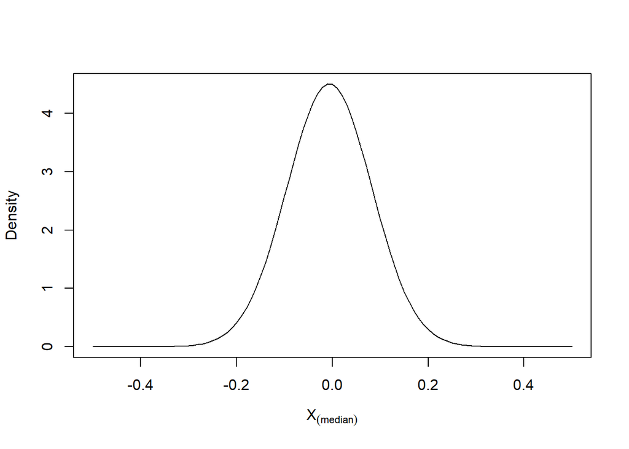

```r
dorder <- function(x){
    100*
    choose(200,100)*
    (pnorm(x, 0, 1))^(100-1)*
    (1-pnorm(x, 0, 1))^(200-100)*
    dnorm(x, 0, 1)
}
curve(dorder(x),-0.5,0.5,xlab = parse(text="X[(median)]"), ylab = "Density")
```

For a random variable with N=200 that fits the standard normal distribution, the density function of its median is shown in the plot above.

## Q2: Write an R function that is the probability function for the median in this sample. Generate a plot of the function.

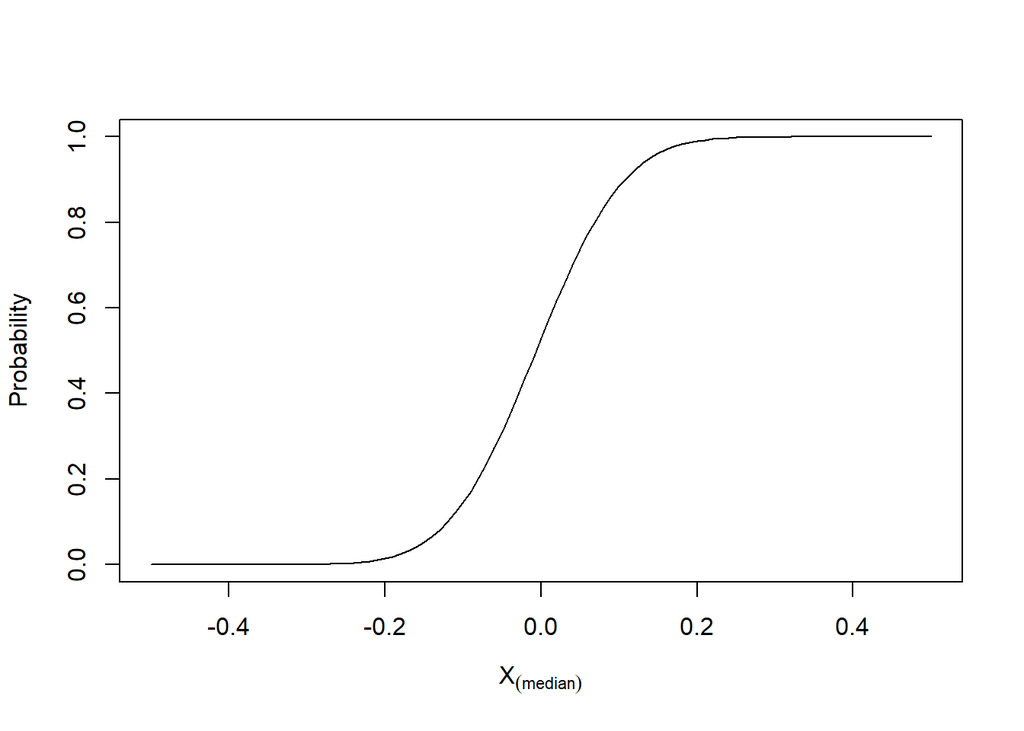

```r
porder <- function(x){
  pbinom(100-1, 200, pnorm(x, 0, 1), lower.tail = FALSE)
}
curve(porder(x),-0.5,0.5,xlab = parse(text="X[(median)]"),ylab = "Probability")
```

For a random variable with N=200 that fits the standard normal distribution, the probability function of its median is shown in the plot above.

## Q3: Write an R function that is the quantile function for the median in this sample. Generate a plot of the function.

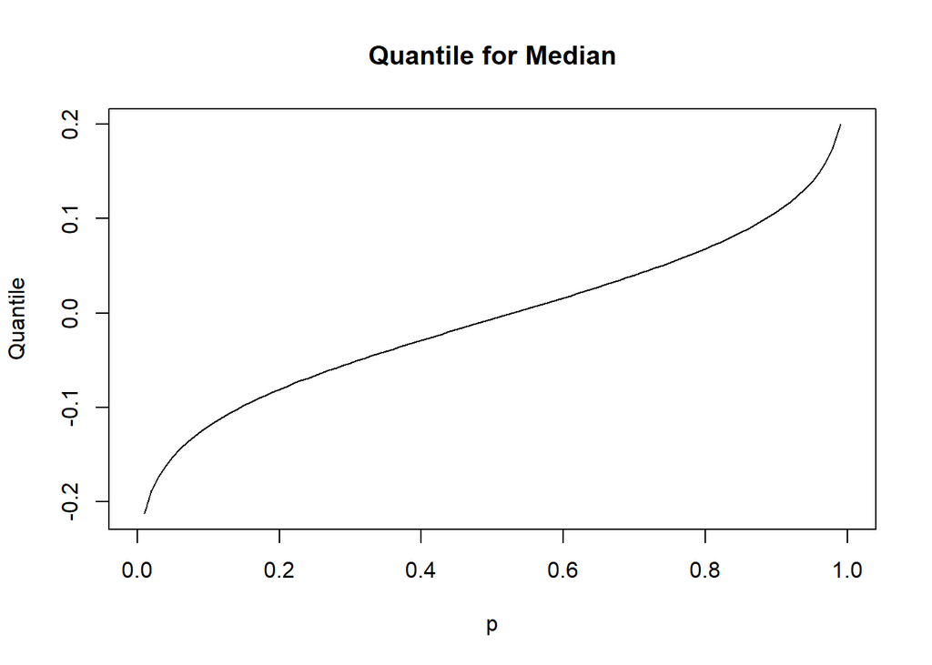

```r
qorder <- function(x){
  lt <- data.frame(x=seq(-0.5,0.5,by=0.001)) %>% mutate(p=porder(x))
  approxfun(lt$p,lt$x)(x)
}
curve(qorder,0,1, main="Quantile for Median",xlab = "p",ylab = "Quantile")
```

For a random variable with N=200 that fits the standard normal distribution, the quantile function of its median is shown in the plot above.

- Note: I set `x=seq(-0.5,0.5,by=0.001)` because it covers the interval in which the median of the standard normal distribution exists

## Q4: Simulate the sampling distribution for the median. Create a plot of the empirical CDF (ECDF). Overlay the plot of the ECDF with a plot of the CDF.

In this question, I using `array` function to simulate a matrix with sample size equal to 200, simulation times equal to 5000 and named it as `data`. In `data`, each row represents the results of one simulation. Thus, by sorting each row and selecting the data of the 100th order statistic, we get a series of numbers `median`, which containing the median of 5000 simulations is obtained. Then we just need to plot it:

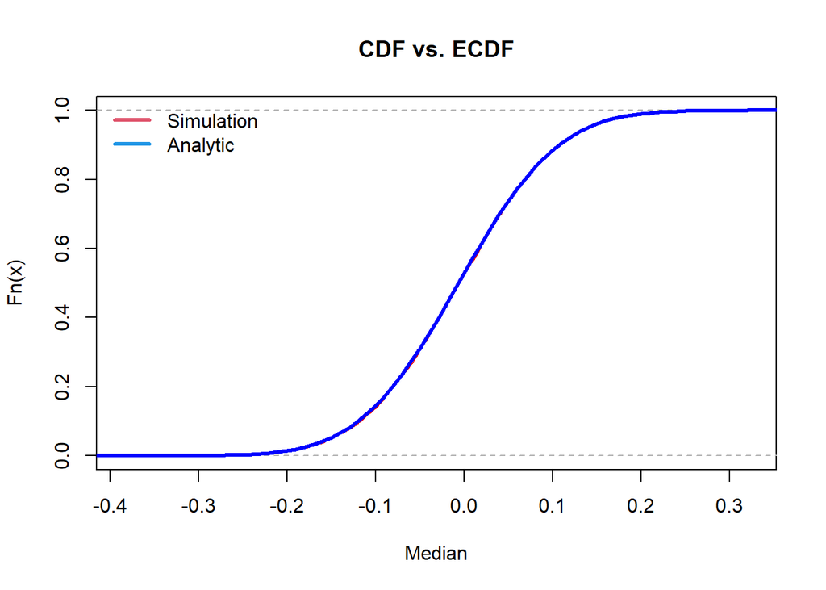

```r
M <- 5000 # simulation times
N <- 200  # sample size
data <- array(rnorm(M*N, 0, 1), c(M, N))
median <- data %>% apply(1, function(x){sort(x)[100]})

plot(ecdf(median), xlab = parse(text = "Median"), main = "CDF vs. ECDF",col="red")
curve(porder(x),-0.5,0.5, lwd = 3, add = TRUE, col = "blue")
legend("topleft",c("Simulation","Analytic"), col = c(2,4), lwd = 3, bty = "n")
```

On the plot above, the median’s ECDF is shown in red and the CDF in blue. Almost no deviation.

## Q5: Using the simulated sampling distribution from the previous question, create a histogram (on the density scale). Overlay the histogram with a plot of the density function.

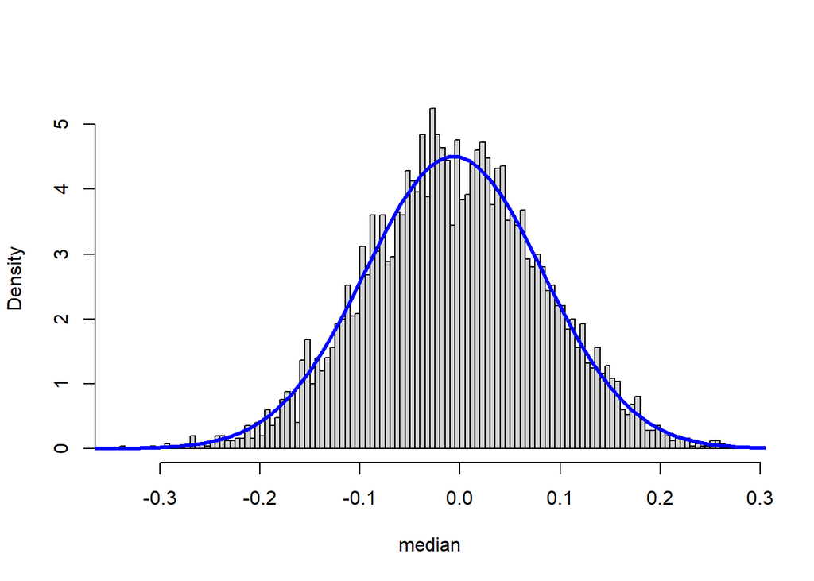

```r
hist(median, breaks = 100, freq = FALSE, main = "")
curve(dorder(x),-0.5,0.5, lwd = 3, add = TRUE, col = "blue")
```

The plot is shown as above.

## Q6: Generate a QQ plot for the simulated data of the median relative to the known sampling distribution of the median. Does the simulated data agree with the theoretical sampling distribution?

The QQ plot, or quantile-quantile plot, is a graphical tool to help us assess if a set of data plausibly came from some theoretical distribution. It allows us to see at-a-glance if our assumption is plausible, and if not, how the assumption is violated and what data points contribute to the violation.

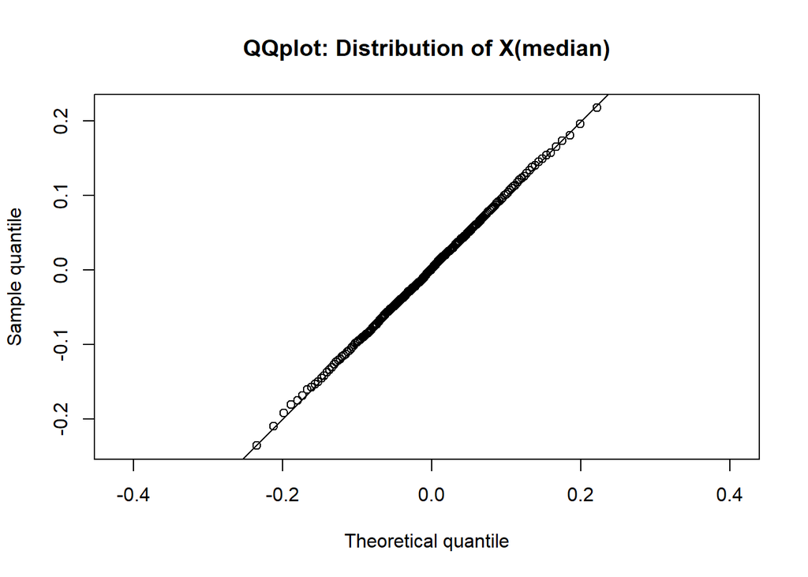

```r
x <- qorder((1:(N-1))/N)
y <- quantile(median,probs = (1:(N-1))/N)

plot(x,y, asp = 1, xlab = "Theoretical quantile", ylab = "Sample quantile",main = "QQplot: Distribution of X(median)")
abline(0,1)
```

Through a QQ plot, the above plot compares a random quantile candidate’s distribution to a theoretical quantile candidate’s distribution.

Plotted points almost match the line y = x (we use this as a reference line), showing that sample quantiles and theoretical quantiles stem from the same distribution.

So from the picture above, we can consider that the simulated data agree with the theoretical sampling distribution.

## Q7: Modify the `dorder`, `porder`, and `qorder` functions so that the functions take a new parameter `k` (for the *k*<sup>*t**h*</sup> order statistic) so that the functions will work for any order statistic and not just the median.

```r
#dorder
dorder7 <- function(x,k){
    k*
    choose(200,k)*
    (pnorm(x, 0, 1))^(k-1)*
    (1-pnorm(x, 0, 1))^(200-k)*
    dnorm(x, 0, 1)
}

#porder
porder7 <- function(x,k){
  pbinom(k-1, 200, pnorm(x,0,1), lower.tail = FALSE)
}

#qorder
qorder7 <- function(x,k){
  lt <- data.frame(x=seq(-5,5,by=0.001)) %>% mutate(p=porder7(x,k))
  approxfun(lt$p,lt$x)(x)
}
```

The modified function is shown above, it can work for any order statistic now.

- Note: for `qorder7` function, I modified the range of $x$ so that `x=seq(-5,5,by=0.001)`, which can cover all the value ranges of the standard normal distribution.

## Q8: Generate the QQ plot for simulated data from the sampling distribution of the sample max and the theoretical largest order statistic distribution.

In this question, first we use a similar approach to the question 4 to obtain a series of numbers which contain the max ($k=N=200$) of 5000 simulations. Then, we use a similar approach to question 6, the only difference is that we use the modified function we get in question 7. Last, draw the plot:

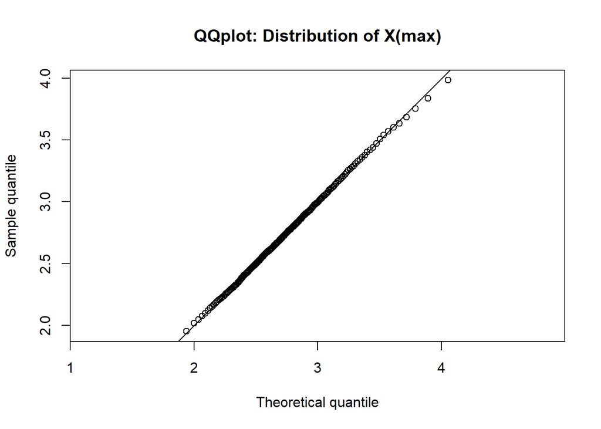

```r
M <- 5000 # simulation times
N <- 200 # sample size
data <- array(rnorm(M*N, 0, 1), c(M, N))
max <- data %>% apply(1, function(x){sort(x)[200]})

x8 <- qorder7((1:(N-1))/N,k=200)
y8 <- quantile(max,probs = (1:(N-1))/N)

plot(x8,y8, asp = 1, xlab = "Theoretical quantile", ylab = "Sample quantile",main = "QQplot: Distribution of X(max)")
abline(0,1)
```

From the picture above, we can consider that the simulated data agree with the theoretical sampling distribution. Almost no deviation.

## Q9: Modify the `dorder`, `porder`, and `qorder` functions so that the functions take new parameters `dist` and `...` so that the functions will work for any continuous distribution that has `d` and `p` functions defined in R.

```r
dorder9 <- function(x,k,n,dist,...){
    pf <- eval(parse(text=paste0("p",dist)))
    df <- eval(parse(text=paste0("d",dist)))
    k*
    choose(n,k)*
    (pf(x,...))^(k-1)*
    (1-pf(x,...))^(n-k)*
    df(x,...)
}

porder9 <- function(x,k,n,dist,...){
  pf <- eval(parse(text=paste0("p",dist)))
  pbinom(k-1, n, pf(x,...), lower.tail = FALSE)
}

qorder9 <- function(x,k,dist,...){
  lt <- data.frame(x=seq(-5,5,by=0.001)) %>% mutate(p=porder7(x,k,dist,...))
  approxfun(lt$p,lt$x)(x)
}
```

## Q10: Use the newly modified functions to plot the probability and density functions for the sample min (*N* = 200).

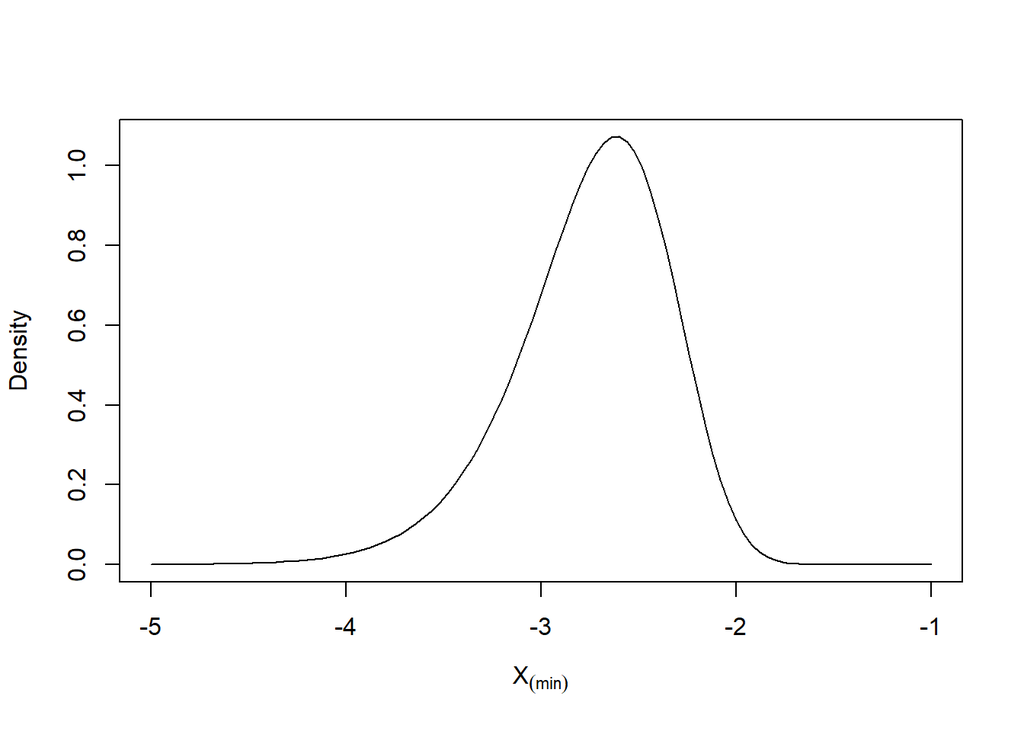

```r
M <- 5000 # simulation times
N <- 200 # sample size
data <- array(rnorm(M*N, 0, 1), c(M, N))
min <- data %>% apply(1, function(x){sort(x)[1]})

curve(dorder9(x,k=1,n=N,"norm",mean=0,sd=1),-5,-1,xlab = parse(text="X[(min)]"), ylab = "Density")
```

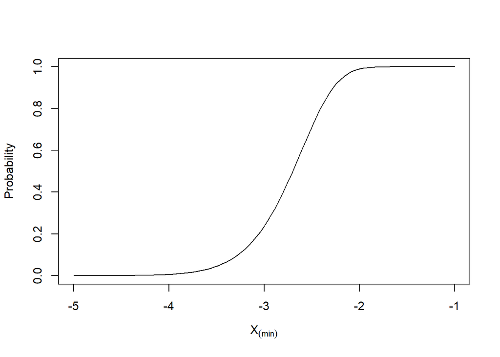

```r
curve(porder9(x,k=1,n=N,"norm",mean=0,sd=1),-5,-1,xlab = parse(text="X[(min)]"),ylab = "Probability")
```

The above plots show the distribution of X[(min)] in CDF and PDF.